# Gathering Data

We are going to regress the return of holding 1M FX forwards against a fairly standard set of macroeconomic and technical indicators. In the past, I’ve done all this using Bloomberg data, but that carries license restrictions. It’s my hope I can use freely available data via Quandl’s interface.

The factors are as follows:

| Factor | Description |
| --- | --- |
| Equity | The 40-day change in the local equity index |
| Spot_40D | The 40-day change in spot rates |
| SwapRate_2Y | The 2Y Swap Rate |
| TwoYear_40D | The 40-day change in 2Y Swap rate |
| YieldCurve | The spread between 10Y and 2Y Swaps |
| FX_Return (endo) | The spot rate change plus the carry return |

All of these factors should be available on a daily basis, but I wouldn’t expect their impact to be felt quite so quickly. In the past, I’ve fit this model on monthly data with at least 15 years’ history. This time, I’m adding CZK and TRY to my usual set of pairs, and I would expect they lack some of the data I’d need, so I may try weekly periodicity on a shorter time period. We’ll see once we get all the data.

Also, clearly, we should expect a high intercorrelation (i.e. multicollinearity) between several of these factors.

Let’s start with the major traded currencies, plus a few popular targets for the carry trade. We will use: AUD, CAD, CHF, CZK, EUR, GBP, JPY, NOK, NZD, SEK, TRY, USD

This will provide a few exogenous shocks, including the Swiss Franc peg, the Brexit panic, the Turkish coup, the taper tantrum, various iterations of the Euro credit crisis, and, if I can get data going far enough back, the 2008 crash. This model is obviously not going to foresee any of these, although it will produce its own covariance estimates for the currencies, which can be used at the portfolio optimization stage if one were to trade on these signals.

Step one is to explore what data is available, and either make changes to the scope of our assets and our factors, or to see what imputation we can make to handle missing data. It’s encouraged to handle missing data directly in the generative model, but I think we’ll have enough parameters just on the Gaussian process.

# Load Libraries

```r
knitr::opts_knit$set(root.dir = normalizePath(".."))
library(tidyverse)
library(Quandl)
library(quantmod)
library(lubridate)
library(ggthemes)
library(GGally) #for scatter plot matrixes
```

# Raw Data

For all currencies, we need 1M funding rates, 2Y and 10Y swaps, equity indexes, and spot rates, all on a daily basis.

Let’s start with the hardest stuff and move up. There’s no point gathering a bunch of information for Turkey, for example, if it turns out I can’t find a reliable 10Y swap rate.

## Swap Rates

It’s quickly become clear that I can’t get swap data for free. So, unfortunately, this demo just became difficult for the reader to duplicate, because I don’t have the right to distribute the rate data I’m going to use. I will keep looking for substitutes, but I don’t want to get bogged down in data as my primary purpose is to demonstrate the model.

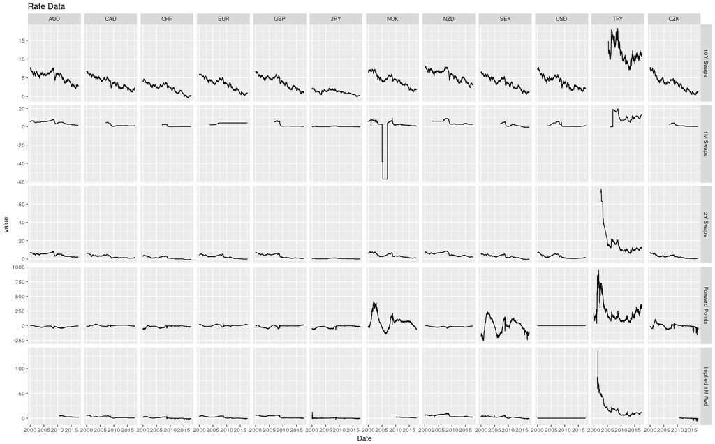

```r
library(readxl)
rate_pages <- c("10Y Swaps", "2Y Swaps", "Forward Points", "1M Swaps", "Implied 1M Fwd")
RATE_PATH <- "../data/proprietary/rates.xlsx"
rates <- map_dfr(rate_pages, read_xlsx, path=RATE_PATH,
                 col_types=c("date",rep("numeric",12)), .id="type")  %>% #read all worksheets on the xlsx file
         mutate(type=factor(rate_pages[as.numeric(type)])) %>% #replace numeric id with the rate page names
         gather(asset, value, -type, -Date, factor_key=T) %>% #flatten the data
         na.omit()
rates %>% ggplot(aes(x=Date,y=value)) + facet_grid(type~asset, scales="free_y") +
  geom_line() + ggtitle("Rate Data")
```

Turkey had a bout of hyperinflation in the early 2000s. I’m not sure what’s going on with those 1M Norway rates, but it’s not right. If we start our data set in 2007, we’ll eliminate these issues and still get to keep the credit crisis.

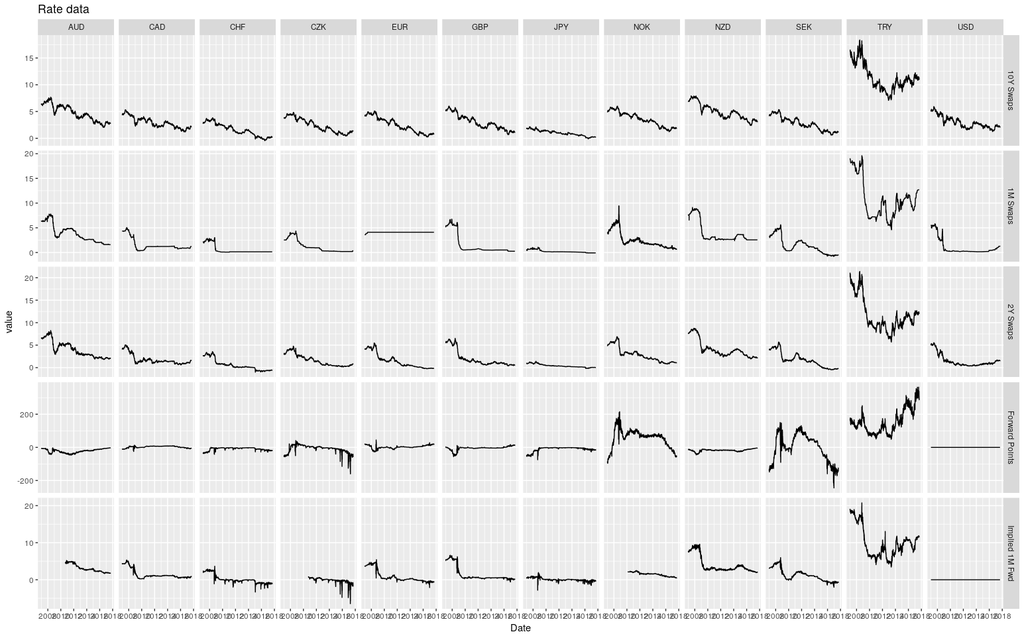

```r
rates %>% filter(Date >= as.Date("2007-01-01")) %>%
  ggplot(aes(x=Date, y=value)) + facet_grid(type~asset, scales="free_y") + geom_line() + ggtitle("Rate data")
```

EUR 1M Swap rate is obviously wrong, too; it’s been the same value for nearly 10 years. The implied rate, which is backed out from the forward points, looks more realistic, but it can be messy.

We can backfill Australia and Norway with the 1M swap data. More worrisome is the choppiness in the forward points (and hence the implied rate) for CHF, CZK, and SEK. I’ve never traded CZK professionally, but I don’t recall having issues with CHF or SEK in those time periods. CHF had a peg for a while. Smoothing misses turning points, and probably doesn’t reflect what we would do in production, on a day where the rates quoted were out of whack. If we could help it, we probably just wouldn’t trade CZK that day.

We’ll see what the final carry return values look like in the next notebook, which calculates factors. If necessary, we can benchmark against the Bloomberg generic carry return indexes (which look like, e.g., `AUDUSDCR Curncy`), but I’m still trying to minimize reliance on Bloomberg.

## Spot Rates

Spot rates, at least, should be freely available. QuantMod weirdly insists on assigning output to variables directly in the environment if you call getSymbols with more than one symbol. We’ll keep things clean by making a new environment.

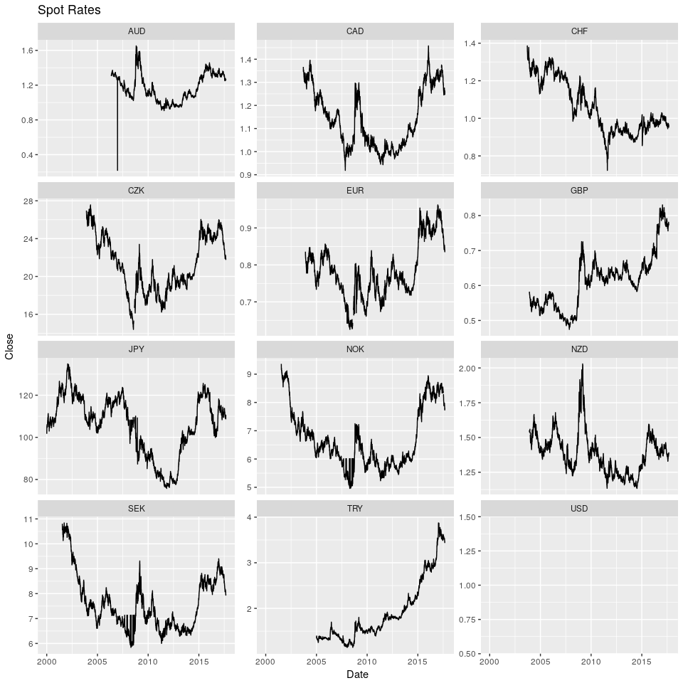

We have some bad values in the Scandies, plus that obvious misquote in AUD. Let’s have a look at the full OHLC for SEK and NOK in the relevant period.

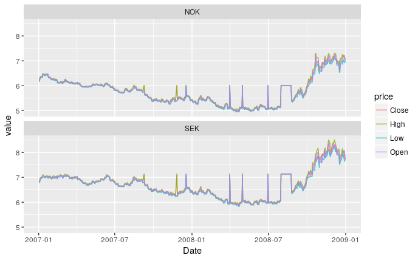

```r
spot %>% filter(asset %in% c("SEK","NOK")) %>%
         filter(Date > as.Date("2007-01-01") & Date <= as.Date("2008-12-31")) %>%
         select(-Volume, -Adjusted) %>%
         gather(price,value,-asset,-Date) %>%
  ggplot(aes(x=Date, y=value, col=price)) + facet_wrap(~asset, ncol=1) +
      geom_line(alpha=0.75)
```

Looks like we’ll have to go elsewhere for the Scandy data, start in 2009, or just skip them for now. I’m inclined to skip; it’ll make the Gaussian Process run faster.

By convention, some currencies are quoted with the USD as the numeraire, others with the local currency as numeraire (AKA an indirect quote). We could have specified the pairs directly by putting ‘USD’ at the end of each ticker above. However, the forward points are given relative to the conventional quote. Store a vector of -1s and 1s, then you can either multiply the returns by that vector, or raise the spot rates to the power of that vector to make everything quoted in the same direction. Too bad R doesn’t have a proper dictionary class.

Yahoo has everything quoted directly. We will want the opposite when calculating returns in USD, i.e. JPY going from 120 to 100 is a positive return for the USD-denominated investor. We need the conventions when adding in the forward points.

```r
SPOT_CONVENTION <- c(AUD=-1, CAD=1, CHF=1, CZK=1, EUR=-1, GBP=-1,
                     JPY=1, NOK=1, NZD=-1, SEK=1, TRY=1)
```

Lastly, to be sure, are my antipodal spots on a Mon-Fri schedule?

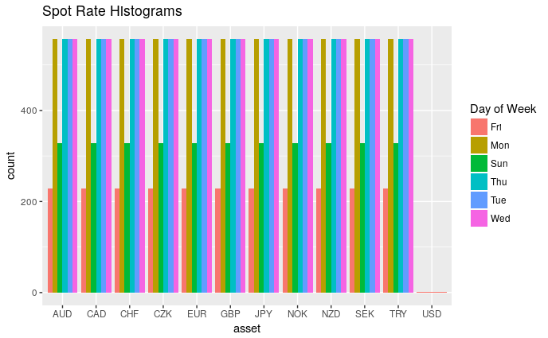

```r
#spot %>% group_by(asset, DoW=format(Date,"%a")) %>% tally()
spot %>% filter(Date>=ymd(20070101)) %>%
  ggplot(aes(x=asset,fill=format(Date,"%a"),value=Close)) +
  geom_bar(position="dodge") + guides(fill=guide_legend(title="Day of Week")) +
  ggtitle("Spot Rate Histograms")
```

…sometimes, for all of them. What is going on, yahoo? Bloomberg never gives me this much grief. The FX markets are open, briefly on Sunday EST, but if you’re going to give me those, there should be as many Sundays as any other day. It certainly doesn’t explain why we have fewer values on Fridays. All I can think of is that it’s varying throughout the year based on daylight savings time, which isn’t observed in Japan.

```r
spot %>% filter(asset=="AUD") %>% group_by(month(Date)) %>% summarize(Fridays=sum(ifelse(weekdays(Date)=="Friday",1,0)),
                                                                      Sundays=sum(ifelse(weekdays(Date)=="Sunday",1,0)))
```

| month(Date) | Fridays | Sundays |
| --- | --- | --- |
| 1 | 49 | 0 |
| 2 | 45 | 0 |
| 3 | 45 | 11 |
| 4 | 0 | 47 |
| 5 | 0 | 51 |
| 6 | 0 | 51 |
| 7 | 0 | 54 |
| 8 | 0 | 53 |
| 9 | 0 | 47 |
| 10 | 4 | 37 |

[output cut: 2 more lines]

That is truly malicious. It doesn’t even make sense, as I don’t think that one hour kicks FX into a new day. Ok, who *else* has spot rates going back that far? Oanda will only give you the last 180 days. Ideally, we want the WMR London Fix, but we’ll actually wind up with weekly carry return, and it seems we can’t afford to be picky. (NZ Forex)[www.nzforex.co.nz] has historical rates, but they’re not the WMR fix, and probably reflect some local time mark.

How about (Open Exchange Rates)[www.openexchangerates.org]? This is getting into territory where Python and pandas do a better job, but let’s try to keep things in R. If you don’t want to pay, you have to make one API call per date to get this data.

```r
for(dt in dts) {
  dt <- as.Date(dt)
  if(year(old_dt) < year(dt)) {
    message(format(dt,"%Y-%m-%d"))
  }
  new_spots[dt] <- get_spot(dt,
                     app_id=scan("~/.openexchange_key", character()),
                     assets=levels(spot$asset))
}
```

```
Read 1 item
Error in open.connection(con, "rb") : HTTP error 429.
```

…but you’re only allowed 1000 requests per month for free. I’m afraid I’m going to have to take Bloomberg data for spot rates, as well. I can at least store the transformed factors publicly, since that is materially altered.

## Equity Indexes

Lastly, equity indexes, at least, should be easy to come by. Maybe I can finally use Quandl for something. …nope. Quandl’s equity index data is out of date. There seems to be nothing worthwhile for free on Quandl.

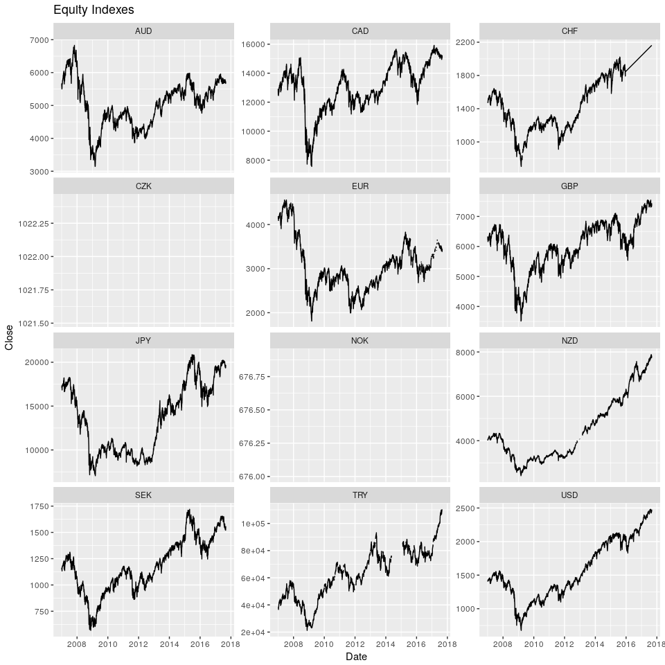

Missing some for CHF, NZD, and TRY, and everything for CZK, and NOK. I’m going to see what I can get directly off the Bourse websites. Typically, they want this data propagated.

```
Unequal factor levels: coercing to characterbinding character and factor vector, coercing into character vectorbinding character and factor vector, coercing into character vector
```

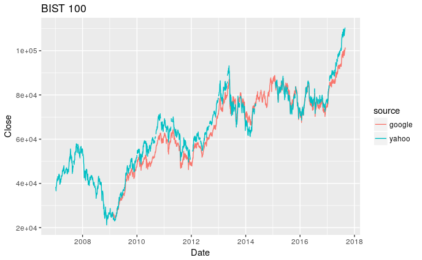

```r
bind_rows(google=equities_goog %>% filter(asset=="TRY"),
          yahoo=equities %>% filter(asset=="TRY"), .id="source") %>%
  ggplot(aes(x=Date,y=Close, col=source)) + geom_line() + ggtitle("BIST 100")
```

Not exactly a drop-in replacement, but it seems reasonable to replace the blank spot in yahoo data.

```r
equities %>% filter(asset == "TRY" & is.na(Close)) %>%
  filter(Date >= as.Date("2014-04-01") & Date <= "2015-03-31") %>%
  select(Date)
```

| Date |
| --- |
| 2014-04-23 |
| 2014-05-01 |
| 2014-05-19 |
| 2014-05-20 |
| 2014-05-21 |
| 2014-05-22 |
| 2014-05-23 |
| 2014-05-26 |
| 2014-05-27 |
| 2014-05-28 |

[output cut: 180 more lines]

2014-05-19 to 2015-02-04

```r
equities <- bind_rows(equities %>% filter(!(asset == "TRY" &
                                              Date >= as.Date("2014-05-19") &
                                              Date <= as.Date("2015-02-04"))),
                      equities_goog %>% filter(asset == "TRY" &
                                              Date >= as.Date("2014-05-19") &
                                              Date <= as.Date("2015-02-04")))
```

```
Unequal factor levels: coercing to characterbinding character and factor vector, coercing into character vectorbinding character and factor vector, coercing into character vector
```

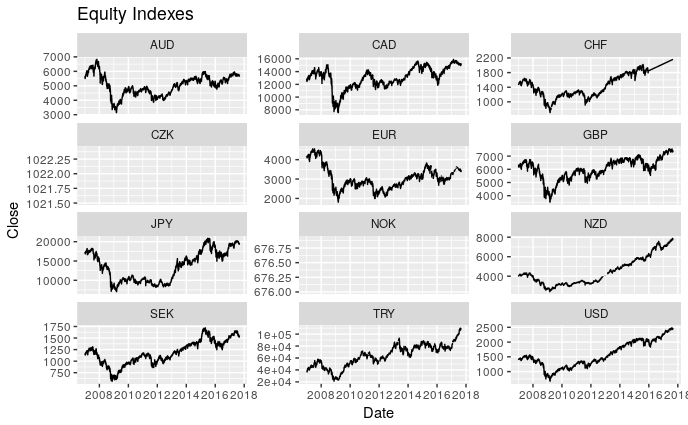

```r
equities %>% ggplot(aes(x=Date, y=Close)) + facet_wrap(~asset, ncol=3, scale="free_y") +
  geom_line() + ggtitle("Equity Indexes")
```

```r
equities <- bind_rows(equities %>% select(-Volume, -Adjusted) %>%
                        filter(!(asset %in% c("CZK","NOK","CHF"))),
                      equities_goog %>% filter(asset =="CHF") %>% select(-Volume),
                      env_eqy$CZK %>% mutate(asset="CZK"),
                      env_eqy$NOK %>% mutate(asset="NOK") %>%
                        filter(Date>=as.Date("2007-01-01")))
```

```
binding character and factor vector, coercing into character vector
```

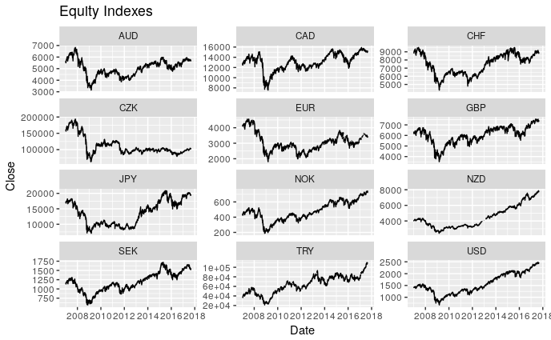

```r
equities %>% ggplot(aes(x=Date,y=Close)) +
  facet_wrap(~asset, ncol=3, scales = "free_y") +
  geom_line() + ggtitle("Equity Indexes")
```

Now we are left with a small discontinuity in NZD. Closer inspection of the data reveals these to be a period with only weekly data, instead of daily. We need equities so we can get the rolling 40-day change. Given that we will be regressing on weekly or monthly periodicity, it’s possible this is going to be good enough. I’m a strong believer in garbage in, garbage out, but it’s unlikely the final portfolio will be permitted to take big positions in NZD in the first place. We can revisit if the factors look wonky around then (possibly filling in with AUD data), or if the final forecast has clearly been affected.

## Cleanup

Let’s clear out the intermediate variables, then save the data and move on to a clean sheet.

```r
rm(rates) ; message("I can't keep unaltered rates data freely accessible.")
```

```
I can't keep unaltered rates data freely accessible.
```

```r
save.image("../data/gathering_data.rData")
```

# In Summary

Even this small set of data took quite a lot of work to get into manageable shape. We still anticipate issues in calculating the carry return, which is our endogenous variable! It is crucial to get this step right, however. It’s ok to take some shortcuts, and backfill some data, where necessary, but we must be aware that we’re doing it, and have justifications for our actions. That’s what makes the notebook workflow, whether RStudio or Jupyter, so crucial. You can come back in a year’s time and see exactly what your logic was.